# CRIMETIME:

# Predict NYC crime rates using historical data.

## Introduction

This is a blog post about the project I completed at [Insight Data Science](http://insightdatascience.com/). The goal of the project was to develop a predictive model for crime rates in New York City using historical data provided by the [NYC Open Data Website](https://nycopendata.socrata.com/). This lead me to create a web application, [CrimeTime](https://crimetime.online), where users can preform similar analysis in their neighborhood anywhere in New York City.

### In this blogpost

In this blog I will be covering a few topics that involve learning from data and developing strategies for combating crime from the data. Specifically I will,

- Perform exploratory analysis on geospatial and temporal crime data to find where and when specific crimes happen the most.

Now that we can predict future montly crime rates in these neighborhoods we can allocate police resources to the neigborhoods at the appropriate time. Finally we look into,

- Performing exploratory data analysis to help us uncover ways to reduce assaults in East Harlem.

Throughout this post I'll be using the classes and methods I developed in the web application. It was useful to use an object oriented approach, so that I have the flexibility of extending the code easily and using it in different environment like this post.

### About the web application

The web application I built was written in [Python](https://www.python.org/) and [Flask](http://flask.pocoo.org/) and was deployed to [Amazon web services.](https://aws.amazon.com/) Users are prompted by to enter an address and then I use geopy library to get the latitude and longitude of the address. Once that latitude and longitude are known I use the shapely library to find out which police precinct the address in and obtain the data and statitics on that police precinct.

The info for police precincts was obtained by scraping the NYPD's [website](http://www.nyc.gov/html/nypd/html/home/precincts.shtml) using beautifulsoup library and also the [NYC Open Data Website](https://nycopendata.socrata.com/). The crime data was obtained from the [NYC Open Data Website](https://nycopendata.socrata.com/) and cleaning was completed using Pandas and GeoPandas. The data was then stored in a [SQLite](https://sqlite.org/) database. Forecasted crime rates were predicted using a seasonal ARIMA model through the python library [Statsmodels](http://statsmodels.sourceforge.net/) using a grid search for the appropriate model paramaters.

The source code for this project can be found [here](https://github.com/mdh266/CrimeTime).

## Exploratory temporal and geospatial data analysis

After downloading and csv data from the NYC Open Data website and cleaning I decided to store it in a sqlite database. This is all done using the "PreProcessor" class, during instantiation we pass it the address and name of our database:

```python
import sys
import os.path
import os
sys.path.append("../backend/")
from PreProcessor import PreProcessor

# Instantiate the preprocessor object
PP = PreProcessor("../data/CrimeTime.db")
```

The actual CSV file is located in the same directory. We can clean this file and create the database CrimeTime.db with the crime data stored on a table called "NYC_Crime" by the following command:

```python
#PP.make_NYC_Crime_database("NYC_Crime")
```

The preprocessor will also scrape the NYPD's [website](http://www.nyc.gov/html/nypd/html/home/precincts.shtml) to obtain the address and telephone number of each precinct police station and store it in the "CrimeTime.db" database as the table "NYC_Precinct_Info" through the command:

```python
#PP.make_NYC_precinct_database()
```

Now that our data is cleaned we can access the it very easily using [sqlite3](https://docs.python.org/2/library/sqlite3.html) database library and read it into a [pandas](http://pandas.pydata.org/) dataframe. We obtain all the crime data on Manhattan by the commands:

```python
import sqlite3
import pandas as pd

# Connect to the database
conn = sqlite3.connect('../data/CrimeTime.db')

# SQL Command
sql_command = 'SELECT * FROM NYC_Crime WHERE BOROUGH = \'MANHATTAN\''

# Now querry the database using the above command
crime_df = pd.read_sql(sql_command, conn)

# close the connection to the database
conn.close()
```

You'll notice I only have data that from 2006 to 2015. The data for 2016 was not available at the time and the data before 2006 is rather sparse. Since the data before 2006 isn't so good and because it might not actually be better for forecasting I decided to neglect it. Let's get a look how crime in Manhattan has evolved over the last 9 years.

We will plot the yearly crime data, but first we must group all the crimes by their year, we do this with Pandas command which creates an new pandas dataframe with the yearly crimes:

```python
CRIMES_PER_YEAR = crime_df.groupby('YEAR').size()
CRIMES_PER_YEAR.head()
```

```
YEAR
2006    34541
2007    32377
2008    31179
2009    27933
2010    26922
dtype: int64
```

The last command shows us the first 5 enteries of the dataframe. We can plot this yearly data directly using the .plot() method on the dataframe. This calls matplotlib library under the hood:

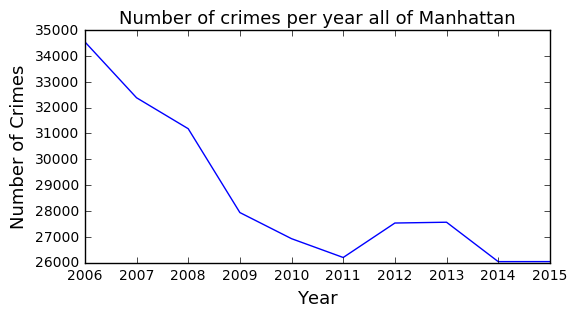

```python
import matplotlib.pyplot as plt
%matplotlib inline
fig = plt.figure(figsize=(6, 3))

# We can use .plot()
CRIMES_PER_YEAR.plot()
plt.xlabel('Year',fontsize=13)
plt.ylabel('Number of Crimes',fontsize=13)
plt.title('Number of crimes per year all of Manhattan',fontsize=13)
plt.ticklabel_format(useOffset=False)
```

One thing to notice is that crime in the last 10 years has been going down!

Let's just look at the crime date for larceny and assault. We can build new dataframes just for these specific crimes with the commands:

```python
LARCENY = crime_df[crime_df.OFFENSE == 'GRAND LARCENY']
ASSAULT = crime_df[crime_df.OFFENSE == 'FELONY ASSAULT']
```

In order to visualize the geospatial distribution of crimes in Manhattan, lets break down our data in to the number of crimes per month (in 2015) that occrur within a precinct. We can do this in pandas using the "groupby' command:

```python
CRIMES_2015 = ASSAULT[ASSAULT.YEAR == 2015]
CRIMES_2015 = CRIMES_2015.groupby('PRECINCT').size()
```

Now that we have the number of crimes per precinct and the precinct geometries (Note: I downloaded them as a geojson file and edited out non-Manhattan police precincts by hand.) we can visualize the number of assaults per precint using Folium. Folium is python package that has very nice geospatial visualization cabilities. Using it we can directly read in the geojson file and then plot the number of crimes that occur each month in a precinct using the choropleth function. Lets visualize the number the assaults in 2015:

```python
import folium
# Central lat/long values of nyc
nyc_coor = [40.81,-73.9999]

# instatiate a folium map object with the above coordinate at center
nyc_crime_map = folium.Map(location=nyc_coor,zoom_start=11)

# the path to the geojson file of the manhattan precincts
pathgeo = './manhattan_precincts.geojson'

# make the chorlopleth map
nyc_crime_map.choropleth(geo_path=pathgeo,
                        data=CRIMES_2015,
                        key_on='feature.properties.Precinct',
                        fill_color='BuPu', fill_opacity=0.7, line_opacity=0.2,
                        legend_name='MANHATTAN')
# show the map
nyc_crime_map
```

[interactive chart not shown]

We can look at the other crimes if we want too, and for the purposes of this blog well just look at Grand Larceny:

```python
CRIMES_2015 = LARCENY[LARCENY.YEAR == 2015]
CRIMES_2015 = CRIMES_2015.groupby('PRECINCT').size()

# instantiate the object
nyc_crime_map = folium.Map(location=nyc_coor,zoom_start=11)

# path to geojson precinct file
pathgeo = './manhattan_precincts.geojson'

# make the map
nyc_crime_map.choropleth(geo_path=pathgeo,
                        data=CRIMES_2015,
                        key_on='feature.properties.Precinct',
                        fill_color='BuPu', fill_opacity=0.7, line_opacity=0.2,
                        legend_name='MANHATTAN')
# show the map
nyc_crime_map
```

[interactive chart not shown]

We can see that Larceny seems to be highest in midtown while assault seems to be highest in East Harlem. We'll focus in on these two neighborhoods and analyze the Larcey in midtown and assaults in East Harlem to see what we can learn from the historical data to help us predict crime in the future and develop a data driven approach to reducing it.

We'll be using the "CrimeMapper" class from the backend to house our data and make our graphics.

```python
from CrimeMapper import CrimeMapper
```

```python
EastHarlem = CrimeMapper(False)
EastHarlem.prec = 23
#EastHarlem.find_precinct("29 E. 109th St. Manhattan, NY.")
EastHarlem.get_crime_data("Assault")
EastHarlem.make_timeseries()
```

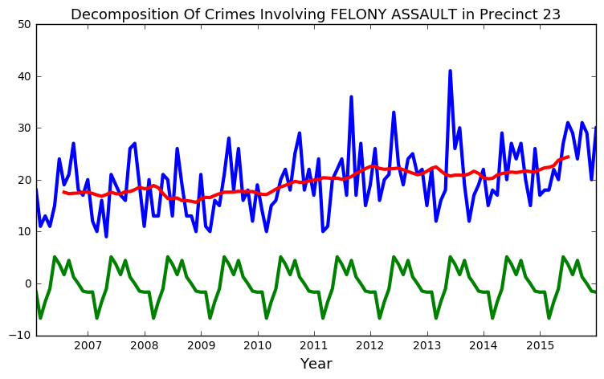

```python
EastHarlem.plot_decompose()
```

```python
Midtown = CrimeMapper(False)
Midtown.prec = 14
#EastHarlem.find_precinct("29 E. 109th St. Manhattan, NY.")
Midtown.get_crime_data("Larceny")
Midtown.make_timeseries()
```

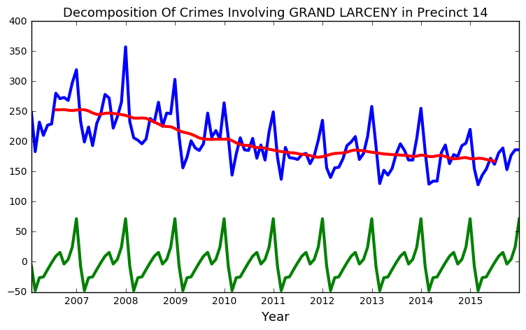

```python
Midtown.plot_decompose()
```

```python
from Forcasting import Seasonal_Arima
```

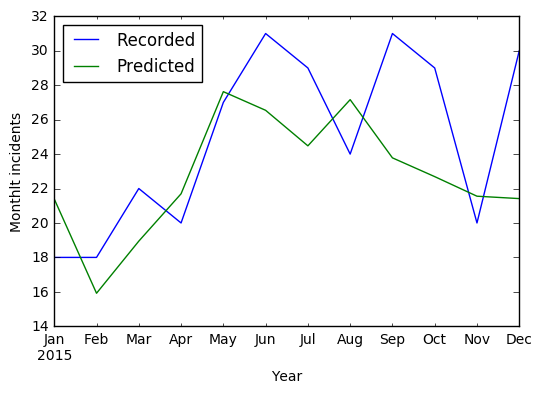

```python
# Instantiate a model on the time series data for East Harlem
Forecast_Harlem = Seasonal_Arima(EastHarlem)

# Fit it to training data. Choose appropriate paramater values
# by doing a grid search and choosing the values with the smallest
# RMSE on the validation set
Forecast_Harlem.fit()

# Plot the dynamic forecast on the validation set
Forecast_Harlem.plot_test()
```

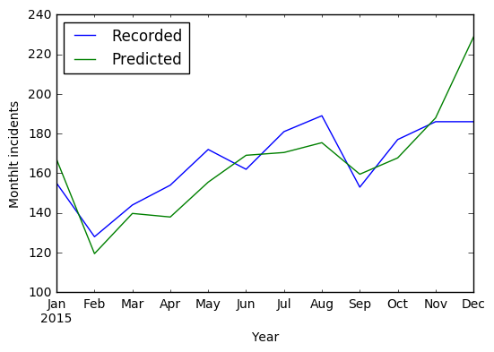

```python
Forecast_Midtown = Seasonal_Arima(Midtown)

Forecast_Midtown.fit()

Forecast_Midtown.plot_test()
```

```python
#Forcast_Harlem.forecast()
#Forcast_Harlem.plot_forecast()
```

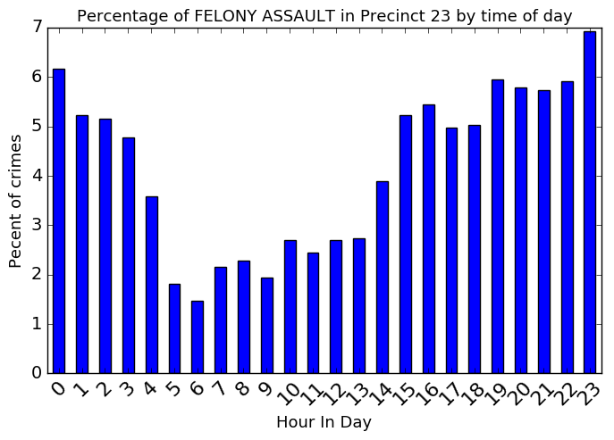

```python
EastHarlem.plot_per_hour()
```

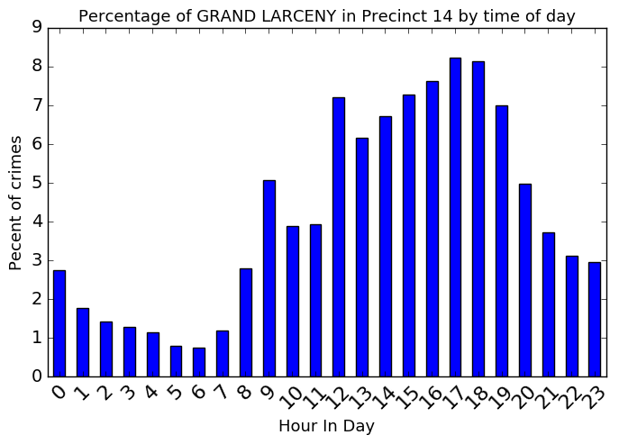

```python
Midtown.plot_per_hour()
```

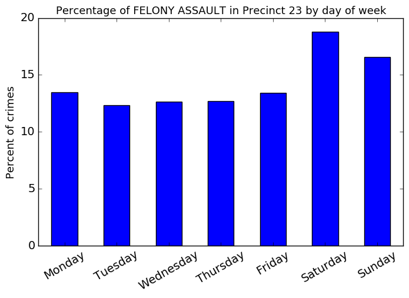

```python
EastHarlem.plot_per_day()
```

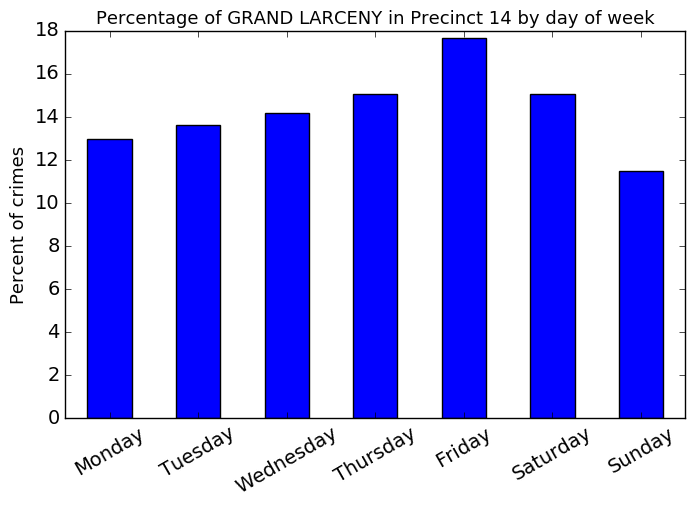

```python
Midtown.plot_per_day()
```